# Risk Factor Analysis

## Outcome Variable

**Outcome Variable:** ever_stunted

## Predictor Variables

**Intervention Variable:** nchldlt5

**Adjustment Set:**

- arm
- W_mage
- meducyrs
- feducyrs
- hhwealth_quart
- hfoodsec
- W_mhtcm
- W_mwtkg
- W_mbmi
- W_nrooms
- W_parity
- impfloor
- impsan
- safeh20
- delta_W_mage
- delta_meducyrs
- delta_feducyrs
- delta_hhwealth_quart
- delta_hfoodsec
- delta_W_mhtcm
- delta_W_mwtkg
- delta_W_mbmi
- delta_W_nrooms
- delta_W_parity
- delta_impfloor
- delta_impsan
- delta_safeh20

## Stratifying Variables

The analysis was stratified on these variable(s):

- agecat
- studyid
- country

## Data Summary

| agecat | studyid | country | nchldlt5 | ever_stunted | n_cell | n |
| --- | --- | --- | --- | --- | --- | --- |
| 0-24 months | iLiNS-Zinc | BURKINA FASO | 1 | 0 | 711 | 3188 |
| 0-24 months | iLiNS-Zinc | BURKINA FASO | 1 | 1 | 362 | 3188 |
| 0-24 months | iLiNS-Zinc | BURKINA FASO | 2+ | 0 | 1339 | 3188 |
| 0-24 months | iLiNS-Zinc | BURKINA FASO | 2+ | 1 | 776 | 3188 |
| 0-24 months | IRC | INDIA | 1 | 0 | 35 | 410 |
| 0-24 months | IRC | INDIA | 1 | 1 | 54 | 410 |
| 0-24 months | IRC | INDIA | 2+ | 0 | 112 | 410 |
| 0-24 months | IRC | INDIA | 2+ | 1 | 209 | 410 |
| 0-24 months | JiVitA-3 | BANGLADESH | 1 | 0 | 8536 | 27200 |
| 0-24 months | JiVitA-3 | BANGLADESH | 1 | 1 | 8874 | 27200 |
| 0-24 months | JiVitA-3 | BANGLADESH | 2+ | 0 | 5189 | 27200 |
| 0-24 months | JiVitA-3 | BANGLADESH | 2+ | 1 | 4601 | 27200 |
| 0-24 months | LCNI-5 | MALAWI | 1 | 0 | 145 | 812 |
| 0-24 months | LCNI-5 | MALAWI | 1 | 1 | 246 | 812 |
| 0-24 months | LCNI-5 | MALAWI | 2+ | 0 | 150 | 812 |
| 0-24 months | LCNI-5 | MALAWI | 2+ | 1 | 271 | 812 |
| 0-24 months | NIH-Crypto | BANGLADESH | 1 | 0 | 298 | 758 |
| 0-24 months | NIH-Crypto | BANGLADESH | 1 | 1 | 243 | 758 |
| 0-24 months | NIH-Crypto | BANGLADESH | 2+ | 0 | 98 | 758 |
| 0-24 months | NIH-Crypto | BANGLADESH | 2+ | 1 | 119 | 758 |
| 0-24 months | PROVIDE | BANGLADESH | 1 | 0 | 295 | 700 |
| 0-24 months | PROVIDE | BANGLADESH | 1 | 1 | 217 | 700 |
| 0-24 months | PROVIDE | BANGLADESH | 2+ | 0 | 100 | 700 |
| 0-24 months | PROVIDE | BANGLADESH | 2+ | 1 | 88 | 700 |
| 0-24 months | TanzaniaChild2 | TANZANIA, UNITED REPUBLIC OF | 1 | 0 | 1077 | 2385 |
| 0-24 months | TanzaniaChild2 | TANZANIA, UNITED REPUBLIC OF | 1 | 1 | 560 | 2385 |
| 0-24 months | TanzaniaChild2 | TANZANIA, UNITED REPUBLIC OF | 2+ | 0 | 481 | 2385 |
| 0-24 months | TanzaniaChild2 | TANZANIA, UNITED REPUBLIC OF | 2+ | 1 | 267 | 2385 |
| 0-6 months | IRC | INDIA | 1 | 0 | 49 | 410 |
| 0-6 months | IRC | INDIA | 1 | 1 | 40 | 410 |
| 0-6 months | IRC | INDIA | 2+ | 0 | 187 | 410 |
| 0-6 months | IRC | INDIA | 2+ | 1 | 134 | 410 |
| 0-6 months | JiVitA-3 | BANGLADESH | 1 | 0 | 9780 | 27134 |
| 0-6 months | JiVitA-3 | BANGLADESH | 1 | 1 | 7579 | 27134 |
| 0-6 months | JiVitA-3 | BANGLADESH | 2+ | 0 | 6146 | 27134 |
| 0-6 months | JiVitA-3 | BANGLADESH | 2+ | 1 | 3629 | 27134 |
| 0-6 months | LCNI-5 | MALAWI | 1 | 0 | 81 | 267 |
| 0-6 months | LCNI-5 | MALAWI | 1 | 1 | 41 | 267 |
| 0-6 months | LCNI-5 | MALAWI | 2+ | 0 | 91 | 267 |
| 0-6 months | LCNI-5 | MALAWI | 2+ | 1 | 54 | 267 |
| 0-6 months | NIH-Crypto | BANGLADESH | 1 | 0 | 386 | 758 |
| 0-6 months | NIH-Crypto | BANGLADESH | 1 | 1 | 155 | 758 |
| 0-6 months | NIH-Crypto | BANGLADESH | 2+ | 0 | 143 | 758 |
| 0-6 months | NIH-Crypto | BANGLADESH | 2+ | 1 | 74 | 758 |
| 0-6 months | PROVIDE | BANGLADESH | 1 | 0 | 383 | 700 |
| 0-6 months | PROVIDE | BANGLADESH | 1 | 1 | 129 | 700 |
| 0-6 months | PROVIDE | BANGLADESH | 2+ | 0 | 149 | 700 |
| 0-6 months | PROVIDE | BANGLADESH | 2+ | 1 | 39 | 700 |
| 0-6 months | TanzaniaChild2 | TANZANIA, UNITED REPUBLIC OF | 1 | 0 | 1311 | 2385 |
| 0-6 months | TanzaniaChild2 | TANZANIA, UNITED REPUBLIC OF | 1 | 1 | 326 | 2385 |
| 0-6 months | TanzaniaChild2 | TANZANIA, UNITED REPUBLIC OF | 2+ | 0 | 609 | 2385 |
| 0-6 months | TanzaniaChild2 | TANZANIA, UNITED REPUBLIC OF | 2+ | 1 | 139 | 2385 |
| 6-24 months | iLiNS-Zinc | BURKINA FASO | 1 | 0 | 711 | 3188 |
| 6-24 months | iLiNS-Zinc | BURKINA FASO | 1 | 1 | 362 | 3188 |
| 6-24 months | iLiNS-Zinc | BURKINA FASO | 2+ | 0 | 1339 | 3188 |
| 6-24 months | iLiNS-Zinc | BURKINA FASO | 2+ | 1 | 776 | 3188 |
| 6-24 months | IRC | INDIA | 1 | 0 | 35 | 236 |
| 6-24 months | IRC | INDIA | 1 | 1 | 14 | 236 |
| 6-24 months | IRC | INDIA | 2+ | 0 | 112 | 236 |
| 6-24 months | IRC | INDIA | 2+ | 1 | 75 | 236 |
| 6-24 months | JiVitA-3 | BANGLADESH | 1 | 0 | 5238 | 10487 |
| 6-24 months | JiVitA-3 | BANGLADESH | 1 | 1 | 1295 | 10487 |
| 6-24 months | JiVitA-3 | BANGLADESH | 2+ | 0 | 2982 | 10487 |
| 6-24 months | JiVitA-3 | BANGLADESH | 2+ | 1 | 972 | 10487 |
| 6-24 months | LCNI-5 | MALAWI | 1 | 0 | 138 | 705 |
| 6-24 months | LCNI-5 | MALAWI | 1 | 1 | 205 | 705 |
| 6-24 months | LCNI-5 | MALAWI | 2+ | 0 | 145 | 705 |
| 6-24 months | LCNI-5 | MALAWI | 2+ | 1 | 217 | 705 |
| 6-24 months | NIH-Crypto | BANGLADESH | 1 | 0 | 280 | 506 |
| 6-24 months | NIH-Crypto | BANGLADESH | 1 | 1 | 88 | 506 |
| 6-24 months | NIH-Crypto | BANGLADESH | 2+ | 0 | 93 | 506 |
| 6-24 months | NIH-Crypto | BANGLADESH | 2+ | 1 | 45 | 506 |
| 6-24 months | PROVIDE | BANGLADESH | 1 | 0 | 238 | 456 |
| 6-24 months | PROVIDE | BANGLADESH | 1 | 1 | 88 | 456 |
| 6-24 months | PROVIDE | BANGLADESH | 2+ | 0 | 81 | 456 |
| 6-24 months | PROVIDE | BANGLADESH | 2+ | 1 | 49 | 456 |
| 6-24 months | TanzaniaChild2 | TANZANIA, UNITED REPUBLIC OF | 1 | 0 | 858 | 1596 |
| 6-24 months | TanzaniaChild2 | TANZANIA, UNITED REPUBLIC OF | 1 | 1 | 234 | 1596 |
| 6-24 months | TanzaniaChild2 | TANZANIA, UNITED REPUBLIC OF | 2+ | 0 | 376 | 1596 |
| 6-24 months | TanzaniaChild2 | TANZANIA, UNITED REPUBLIC OF | 2+ | 1 | 128 | 1596 |

The following strata were considered:

- agecat: 0-24 months, studyid: iLiNS-Zinc, country: BURKINA FASO
- agecat: 0-24 months, studyid: IRC, country: INDIA
- agecat: 0-24 months, studyid: JiVitA-3, country: BANGLADESH
- agecat: 0-24 months, studyid: LCNI-5, country: MALAWI
- agecat: 0-24 months, studyid: NIH-Crypto, country: BANGLADESH
- agecat: 0-24 months, studyid: PROVIDE, country: BANGLADESH
- agecat: 0-24 months, studyid: TanzaniaChild2, country: TANZANIA, UNITED REPUBLIC OF
- agecat: 0-6 months, studyid: IRC, country: INDIA
- agecat: 0-6 months, studyid: JiVitA-3, country: BANGLADESH
- agecat: 0-6 months, studyid: LCNI-5, country: MALAWI
- agecat: 0-6 months, studyid: NIH-Crypto, country: BANGLADESH
- agecat: 0-6 months, studyid: PROVIDE, country: BANGLADESH
- agecat: 0-6 months, studyid: TanzaniaChild2, country: TANZANIA, UNITED REPUBLIC OF
- agecat: 6-24 months, studyid: iLiNS-Zinc, country: BURKINA FASO
- agecat: 6-24 months, studyid: IRC, country: INDIA
- agecat: 6-24 months, studyid: JiVitA-3, country: BANGLADESH
- agecat: 6-24 months, studyid: LCNI-5, country: MALAWI
- agecat: 6-24 months, studyid: NIH-Crypto, country: BANGLADESH
- agecat: 6-24 months, studyid: PROVIDE, country: BANGLADESH
- agecat: 6-24 months, studyid: TanzaniaChild2, country: TANZANIA, UNITED REPUBLIC OF

## Methods Detail

We're interested in the causal parameters $E[Y_a]$ for all values of $a \in \mathcal{A}$. These parameters represent the mean outcome if, possibly contrary to fact, we intervened to set all units to have $A=a$. Under the randomization and positivity assumptions, these are identified by the statistical parameters $\psi_a=E_W[E_{Y|A,W}(Y|A=a,W)]$. In addition, we're interested in the mean of $Y$, $E[Y]$ under no intervention (the observed mean). We will estimate these parameters by using SuperLearner to fit the relevant likelihood factors -- $E_{Y|A,W}(Y|A=a,W)$ and $p(A=a|W)$, and then updating our likelihood fit using a joint TMLE.

For unadjusted analyses ($W=\{\}$), initial likelihoods were estimated using Lrnr_glm to estimate the simple $E(Y|A)$ and Lrnr_mean to estimate $p(A)$. For adjusted analyses, a small library containing Lrnr_glmnet, Lrnr_xgboost, and Lrnr_mean was used.

Having estimated these parameters, we will then use the delta method to estimate relative risks and attributable risks relative to a prespecified baseline level of $A$.

# Results Detail

## Results Plots

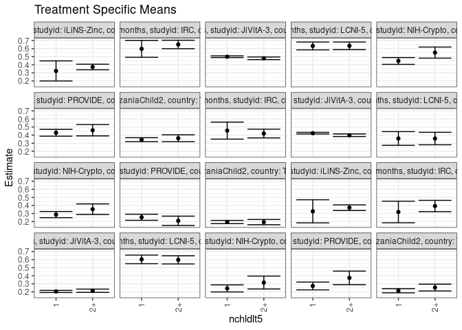

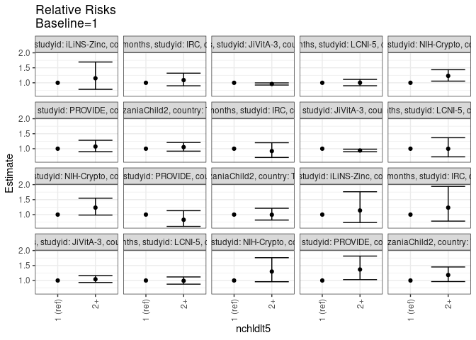

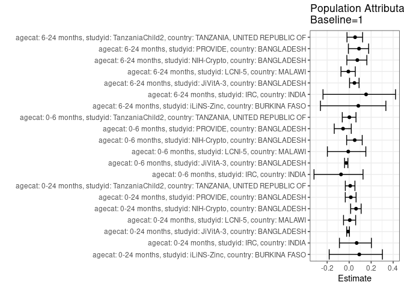

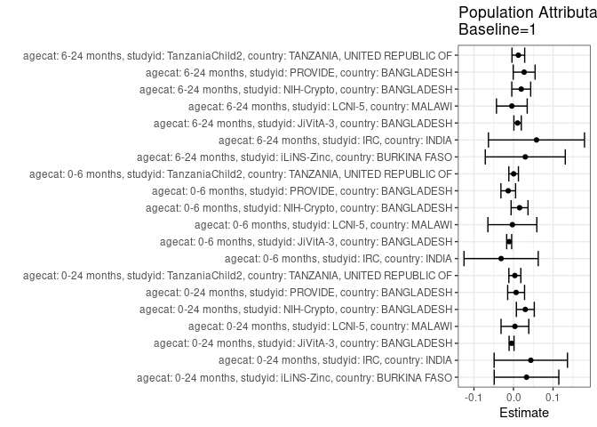

## Results Table

### Parameter: TSM

| agecat | studyid | country | intervention_level | baseline_level | estimate | ci_lower | ci_upper |
| --- | --- | --- | --- | --- | --- | --- | --- |
| 0-24 months | iLiNS-Zinc | BURKINA FASO | 1 | NA | 0.3240462 | 0.1994544 | 0.4486379 |
| 0-24 months | iLiNS-Zinc | BURKINA FASO | 2+ | NA | 0.3728818 | 0.3382738 | 0.4074898 |
| 0-24 months | IRC | INDIA | 1 | NA | 0.5976921 | 0.4930680 | 0.7023162 |
| 0-24 months | IRC | INDIA | 2+ | NA | 0.6517141 | 0.5994007 | 0.7040276 |
| 0-24 months | JiVitA-3 | BANGLADESH | 1 | NA | 0.5002465 | 0.4899210 | 0.5105721 |
| 0-24 months | JiVitA-3 | BANGLADESH | 2+ | NA | 0.4805000 | 0.4642536 | 0.4967465 |
| 0-24 months | LCNI-5 | MALAWI | 1 | NA | 0.6330862 | 0.5846379 | 0.6815346 |
| 0-24 months | LCNI-5 | MALAWI | 2+ | NA | 0.6343390 | 0.5871615 | 0.6815165 |
| 0-24 months | NIH-Crypto | BANGLADESH | 1 | NA | 0.4476391 | 0.4055885 | 0.4896897 |
| 0-24 months | NIH-Crypto | BANGLADESH | 2+ | NA | 0.5510720 | 0.4823201 | 0.6198238 |
| 0-24 months | PROVIDE | BANGLADESH | 1 | NA | 0.4290734 | 0.3867181 | 0.4714288 |
| 0-24 months | PROVIDE | BANGLADESH | 2+ | NA | 0.4602233 | 0.3903489 | 0.5300977 |
| 0-24 months | TanzaniaChild2 | TANZANIA, UNITED REPUBLIC OF | 1 | NA | 0.3433120 | 0.3188429 | 0.3677810 |
| 0-24 months | TanzaniaChild2 | TANZANIA, UNITED REPUBLIC OF | 2+ | NA | 0.3613715 | 0.3188370 | 0.4039061 |
| 0-6 months | IRC | INDIA | 1 | NA | 0.4556635 | 0.3501984 | 0.5611286 |
| 0-6 months | IRC | INDIA | 2+ | NA | 0.4194465 | 0.3653164 | 0.4735767 |
| 0-6 months | JiVitA-3 | BANGLADESH | 1 | NA | 0.4239865 | 0.4138411 | 0.4341319 |
| 0-6 months | JiVitA-3 | BANGLADESH | 2+ | NA | 0.3983274 | 0.3819685 | 0.4146862 |
| 0-6 months | LCNI-5 | MALAWI | 1 | NA | 0.3586430 | 0.2739598 | 0.4433262 |
| 0-6 months | LCNI-5 | MALAWI | 2+ | NA | 0.3577543 | 0.2805666 | 0.4349419 |
| 0-6 months | NIH-Crypto | BANGLADESH | 1 | NA | 0.2867781 | 0.2484844 | 0.3250719 |
| 0-6 months | NIH-Crypto | BANGLADESH | 2+ | NA | 0.3535738 | 0.2882081 | 0.4189396 |
| 0-6 months | PROVIDE | BANGLADESH | 1 | NA | 0.2532645 | 0.2158101 | 0.2907189 |
| 0-6 months | PROVIDE | BANGLADESH | 2+ | NA | 0.2096819 | 0.1519924 | 0.2673714 |
| 0-6 months | TanzaniaChild2 | TANZANIA, UNITED REPUBLIC OF | 1 | NA | 0.1946103 | 0.1744584 | 0.2147622 |
| 0-6 months | TanzaniaChild2 | TANZANIA, UNITED REPUBLIC OF | 2+ | NA | 0.1936302 | 0.1611636 | 0.2260967 |
| 6-24 months | iLiNS-Zinc | BURKINA FASO | 1 | NA | 0.3271410 | 0.1840642 | 0.4702177 |
| 6-24 months | iLiNS-Zinc | BURKINA FASO | 2+ | NA | 0.3722263 | 0.3370451 | 0.4074076 |
| 6-24 months | IRC | INDIA | 1 | NA | 0.3190502 | 0.1853559 | 0.4527445 |
| 6-24 months | IRC | INDIA | 2+ | NA | 0.3930209 | 0.3229918 | 0.4630500 |
| 6-24 months | JiVitA-3 | BANGLADESH | 1 | NA | 0.2057869 | 0.1928187 | 0.2187550 |
| 6-24 months | JiVitA-3 | BANGLADESH | 2+ | NA | 0.2143550 | 0.1940309 | 0.2346791 |
| 6-24 months | LCNI-5 | MALAWI | 1 | NA | 0.6027890 | 0.5493363 | 0.6562416 |
| 6-24 months | LCNI-5 | MALAWI | 2+ | NA | 0.5971822 | 0.5464988 | 0.6478655 |
| 6-24 months | NIH-Crypto | BANGLADESH | 1 | NA | 0.2432771 | 0.1997086 | 0.2868457 |
| 6-24 months | NIH-Crypto | BANGLADESH | 2+ | NA | 0.3160627 | 0.2361566 | 0.3959688 |
| 6-24 months | PROVIDE | BANGLADESH | 1 | NA | 0.2734899 | 0.2252444 | 0.3217353 |
| 6-24 months | PROVIDE | BANGLADESH | 2+ | NA | 0.3737830 | 0.2896465 | 0.4579196 |
| 6-24 months | TanzaniaChild2 | TANZANIA, UNITED REPUBLIC OF | 1 | NA | 0.2145716 | 0.1889426 | 0.2402005 |
| 6-24 months | TanzaniaChild2 | TANZANIA, UNITED REPUBLIC OF | 2+ | NA | 0.2537900 | 0.2116440 | 0.2959360 |

### Parameter: E(Y)

| agecat | studyid | country | intervention_level | baseline_level | estimate | ci_lower | ci_upper |
| --- | --- | --- | --- | --- | --- | --- | --- |
| 0-24 months | iLiNS-Zinc | BURKINA FASO | NA | NA | 0.3569636 | 0.3068991 | 0.4070281 |
| 0-24 months | IRC | INDIA | NA | NA | 0.6414634 | 0.5949863 | 0.6879405 |
| 0-24 months | JiVitA-3 | BANGLADESH | NA | NA | 0.4954044 | 0.4875673 | 0.5032416 |
| 0-24 months | LCNI-5 | MALAWI | NA | NA | 0.6366995 | 0.6035988 | 0.6698003 |
| 0-24 months | NIH-Crypto | BANGLADESH | NA | NA | 0.4775726 | 0.4419904 | 0.5131548 |
| 0-24 months | PROVIDE | BANGLADESH | NA | NA | 0.4357143 | 0.3989556 | 0.4724730 |
| 0-24 months | TanzaniaChild2 | TANZANIA, UNITED REPUBLIC OF | NA | NA | 0.3467505 | 0.3276457 | 0.3658554 |
| 0-6 months | IRC | INDIA | NA | NA | 0.4243902 | 0.3764905 | 0.4722900 |
| 0-6 months | JiVitA-3 | BANGLADESH | NA | NA | 0.4130611 | 0.4056124 | 0.4205098 |
| 0-6 months | LCNI-5 | MALAWI | NA | NA | 0.3558052 | 0.2982716 | 0.4133389 |
| 0-6 months | NIH-Crypto | BANGLADESH | NA | NA | 0.3021108 | 0.2694011 | 0.3348205 |
| 0-6 months | PROVIDE | BANGLADESH | NA | NA | 0.2400000 | 0.2083392 | 0.2716608 |
| 0-6 months | TanzaniaChild2 | TANZANIA, UNITED REPUBLIC OF | NA | NA | 0.1949686 | 0.1790654 | 0.2108717 |
| 6-24 months | iLiNS-Zinc | BURKINA FASO | NA | NA | 0.3569636 | 0.3068991 | 0.4070281 |
| 6-24 months | IRC | INDIA | NA | NA | 0.3771186 | 0.3151523 | 0.4390850 |
| 6-24 months | JiVitA-3 | BANGLADESH | NA | NA | 0.2161724 | 0.2067972 | 0.2255476 |
| 6-24 months | LCNI-5 | MALAWI | NA | NA | 0.5985816 | 0.5623721 | 0.6347910 |
| 6-24 months | NIH-Crypto | BANGLADESH | NA | NA | 0.2628458 | 0.2244546 | 0.3012371 |
| 6-24 months | PROVIDE | BANGLADESH | NA | NA | 0.3004386 | 0.2583143 | 0.3425629 |
| 6-24 months | TanzaniaChild2 | TANZANIA, UNITED REPUBLIC OF | NA | NA | 0.2268170 | 0.2062654 | 0.2473687 |

### Parameter: RR

| agecat | studyid | country | intervention_level | baseline_level | estimate | ci_lower | ci_upper |
| --- | --- | --- | --- | --- | --- | --- | --- |
| 0-24 months | iLiNS-Zinc | BURKINA FASO | 1 | 1 | 1.0000000 | 1.0000000 | 1.0000000 |
| 0-24 months | iLiNS-Zinc | BURKINA FASO | 2+ | 1 | 1.1507057 | 0.7819849 | 1.6932856 |
| 0-24 months | IRC | INDIA | 1 | 1 | 1.0000000 | 1.0000000 | 1.0000000 |
| 0-24 months | IRC | INDIA | 2+ | 1 | 1.0903843 | 0.8999773 | 1.3210754 |
| 0-24 months | JiVitA-3 | BANGLADESH | 1 | 1 | 1.0000000 | 1.0000000 | 1.0000000 |
| 0-24 months | JiVitA-3 | BANGLADESH | 2+ | 1 | 0.9605265 | 0.9257371 | 0.9966232 |
| 0-24 months | LCNI-5 | MALAWI | 1 | 1 | 1.0000000 | 1.0000000 | 1.0000000 |
| 0-24 months | LCNI-5 | MALAWI | 2+ | 1 | 1.0019788 | 0.9018975 | 1.1131658 |
| 0-24 months | NIH-Crypto | BANGLADESH | 1 | 1 | 1.0000000 | 1.0000000 | 1.0000000 |
| 0-24 months | NIH-Crypto | BANGLADESH | 2+ | 1 | 1.2310631 | 1.0553613 | 1.4360167 |
| 0-24 months | PROVIDE | BANGLADESH | 1 | 1 | 1.0000000 | 1.0000000 | 1.0000000 |
| 0-24 months | PROVIDE | BANGLADESH | 2+ | 1 | 1.0725981 | 0.8985765 | 1.2803214 |
| 0-24 months | TanzaniaChild2 | TANZANIA, UNITED REPUBLIC OF | 1 | 1 | 1.0000000 | 1.0000000 | 1.0000000 |
| 0-24 months | TanzaniaChild2 | TANZANIA, UNITED REPUBLIC OF | 2+ | 1 | 1.0526040 | 0.9178517 | 1.2071397 |
| 0-6 months | IRC | INDIA | 1 | 1 | 1.0000000 | 1.0000000 | 1.0000000 |
| 0-6 months | IRC | INDIA | 2+ | 1 | 0.9205182 | 0.7066995 | 1.1990297 |
| 0-6 months | JiVitA-3 | BANGLADESH | 1 | 1 | 1.0000000 | 1.0000000 | 1.0000000 |
| 0-6 months | JiVitA-3 | BANGLADESH | 2+ | 1 | 0.9394812 | 0.8971164 | 0.9838466 |
| 0-6 months | LCNI-5 | MALAWI | 1 | 1 | 1.0000000 | 1.0000000 | 1.0000000 |
| 0-6 months | LCNI-5 | MALAWI | 2+ | 1 | 0.9975218 | 0.7283464 | 1.3661766 |
| 0-6 months | NIH-Crypto | BANGLADESH | 1 | 1 | 1.0000000 | 1.0000000 | 1.0000000 |
| 0-6 months | NIH-Crypto | BANGLADESH | 2+ | 1 | 1.2329177 | 0.9834219 | 1.5457110 |
| 0-6 months | PROVIDE | BANGLADESH | 1 | 1 | 1.0000000 | 1.0000000 | 1.0000000 |
| 0-6 months | PROVIDE | BANGLADESH | 2+ | 1 | 0.8279166 | 0.6065322 | 1.1301064 |
| 0-6 months | TanzaniaChild2 | TANZANIA, UNITED REPUBLIC OF | 1 | 1 | 1.0000000 | 1.0000000 | 1.0000000 |
| 0-6 months | TanzaniaChild2 | TANZANIA, UNITED REPUBLIC OF | 2+ | 1 | 0.9949636 | 0.8179174 | 1.2103331 |
| 6-24 months | iLiNS-Zinc | BURKINA FASO | 1 | 1 | 1.0000000 | 1.0000000 | 1.0000000 |
| 6-24 months | iLiNS-Zinc | BURKINA FASO | 2+ | 1 | 1.1378164 | 0.7348899 | 1.7616600 |
| 6-24 months | IRC | INDIA | 1 | 1 | 1.0000000 | 1.0000000 | 1.0000000 |
| 6-24 months | IRC | INDIA | 2+ | 1 | 1.2318465 | 0.7826029 | 1.9389728 |
| 6-24 months | JiVitA-3 | BANGLADESH | 1 | 1 | 1.0000000 | 1.0000000 | 1.0000000 |
| 6-24 months | JiVitA-3 | BANGLADESH | 2+ | 1 | 1.0416360 | 0.9337764 | 1.1619542 |
| 6-24 months | LCNI-5 | MALAWI | 1 | 1 | 1.0000000 | 1.0000000 | 1.0000000 |
| 6-24 months | LCNI-5 | MALAWI | 2+ | 1 | 0.9906986 | 0.8775553 | 1.1184295 |
| 6-24 months | NIH-Crypto | BANGLADESH | 1 | 1 | 1.0000000 | 1.0000000 | 1.0000000 |
| 6-24 months | NIH-Crypto | BANGLADESH | 2+ | 1 | 1.2991878 | 0.9587804 | 1.7604540 |
| 6-24 months | PROVIDE | BANGLADESH | 1 | 1 | 1.0000000 | 1.0000000 | 1.0000000 |
| 6-24 months | PROVIDE | BANGLADESH | 2+ | 1 | 1.3667162 | 1.0293726 | 1.8146133 |
| 6-24 months | TanzaniaChild2 | TANZANIA, UNITED REPUBLIC OF | 1 | 1 | 1.0000000 | 1.0000000 | 1.0000000 |
| 6-24 months | TanzaniaChild2 | TANZANIA, UNITED REPUBLIC OF | 2+ | 1 | 1.1827755 | 0.9642966 | 1.4507548 |

### Parameter: PAR

| agecat | studyid | country | intervention_level | baseline_level | estimate | ci_lower | ci_upper |
| --- | --- | --- | --- | --- | --- | --- | --- |
| 0-24 months | iLiNS-Zinc | BURKINA FASO | 1 | NA | 0.0329175 | -0.0487621 | 0.1145970 |
| 0-24 months | IRC | INDIA | 1 | NA | 0.0437713 | -0.0489124 | 0.1364550 |
| 0-24 months | JiVitA-3 | BANGLADESH | 1 | NA | -0.0048421 | -0.0110622 | 0.0013779 |
| 0-24 months | LCNI-5 | MALAWI | 1 | NA | 0.0036133 | -0.0314579 | 0.0386844 |
| 0-24 months | NIH-Crypto | BANGLADESH | 1 | NA | 0.0299335 | 0.0072965 | 0.0525704 |
| 0-24 months | PROVIDE | BANGLADESH | 1 | NA | 0.0066409 | -0.0147182 | 0.0280000 |
| 0-24 months | TanzaniaChild2 | TANZANIA, UNITED REPUBLIC OF | 1 | NA | 0.0034386 | -0.0117001 | 0.0185773 |
| 0-6 months | IRC | INDIA | 1 | NA | -0.0312733 | -0.1250859 | 0.0625394 |
| 0-6 months | JiVitA-3 | BANGLADESH | 1 | NA | -0.0109254 | -0.0172114 | -0.0046394 |
| 0-6 months | LCNI-5 | MALAWI | 1 | NA | -0.0028378 | -0.0646961 | 0.0590205 |
| 0-6 months | NIH-Crypto | BANGLADESH | 1 | NA | 0.0153327 | -0.0060296 | 0.0366949 |
| 0-6 months | PROVIDE | BANGLADESH | 1 | NA | -0.0132645 | -0.0318096 | 0.0052807 |
| 0-6 months | TanzaniaChild2 | TANZANIA, UNITED REPUBLIC OF | 1 | NA | 0.0003582 | -0.0117738 | 0.0124903 |
| 6-24 months | iLiNS-Zinc | BURKINA FASO | 1 | NA | 0.0298226 | -0.0713249 | 0.1309702 |
| 6-24 months | IRC | INDIA | 1 | NA | 0.0580684 | -0.0633506 | 0.1794875 |
| 6-24 months | JiVitA-3 | BANGLADESH | 1 | NA | 0.0103855 | 0.0010547 | 0.0197163 |
| 6-24 months | LCNI-5 | MALAWI | 1 | NA | -0.0042074 | -0.0430657 | 0.0346510 |
| 6-24 months | NIH-Crypto | BANGLADESH | 1 | NA | 0.0195687 | -0.0043361 | 0.0434735 |
| 6-24 months | PROVIDE | BANGLADESH | 1 | NA | 0.0269487 | -0.0007426 | 0.0546400 |
| 6-24 months | TanzaniaChild2 | TANZANIA, UNITED REPUBLIC OF | 1 | NA | 0.0122455 | -0.0038280 | 0.0283189 |

### Parameter: PAF

| agecat | studyid | country | intervention_level | baseline_level | estimate | ci_lower | ci_upper |
| --- | --- | --- | --- | --- | --- | --- | --- |
| 0-24 months | iLiNS-Zinc | BURKINA FASO | 1 | NA | 0.0922152 | -0.1811875 | 0.3023349 |
| 0-24 months | IRC | INDIA | 1 | NA | 0.0682366 | -0.0882862 | 0.2022476 |
| 0-24 months | JiVitA-3 | BANGLADESH | 1 | NA | -0.0097741 | -0.0223985 | 0.0026944 |
| 0-24 months | LCNI-5 | MALAWI | 1 | NA | 0.0056750 | -0.0509657 | 0.0592632 |
| 0-24 months | NIH-Crypto | BANGLADESH | 1 | NA | 0.0626784 | 0.0138492 | 0.1090898 |
| 0-24 months | PROVIDE | BANGLADESH | 1 | NA | 0.0152414 | -0.0350263 | 0.0630677 |
| 0-24 months | TanzaniaChild2 | TANZANIA, UNITED REPUBLIC OF | 1 | NA | 0.0099166 | -0.0347272 | 0.0526341 |
| 0-6 months | IRC | INDIA | 1 | NA | -0.0736899 | -0.3193042 | 0.1261986 |
| 0-6 months | JiVitA-3 | BANGLADESH | 1 | NA | -0.0264499 | -0.0417479 | -0.0113765 |
| 0-6 months | LCNI-5 | MALAWI | 1 | NA | -0.0079757 | -0.1977218 | 0.1517103 |
| 0-6 months | NIH-Crypto | BANGLADESH | 1 | NA | 0.0507518 | -0.0226349 | 0.1188721 |
| 0-6 months | PROVIDE | BANGLADESH | 1 | NA | -0.0552687 | -0.1354321 | 0.0192351 |
| 0-6 months | TanzaniaChild2 | TANZANIA, UNITED REPUBLIC OF | 1 | NA | 0.0018374 | -0.0623716 | 0.0621657 |
| 6-24 months | iLiNS-Zinc | BURKINA FASO | 1 | NA | 0.0835453 | -0.2608847 | 0.3338890 |
| 6-24 months | IRC | INDIA | 1 | NA | 0.1539792 | -0.2375332 | 0.4216307 |
| 6-24 months | JiVitA-3 | BANGLADESH | 1 | NA | 0.0480428 | 0.0039175 | 0.0902134 |
| 6-24 months | LCNI-5 | MALAWI | 1 | NA | -0.0070289 | -0.0740801 | 0.0558365 |
| 6-24 months | NIH-Crypto | BANGLADESH | 1 | NA | 0.0744494 | -0.0208705 | 0.1608691 |
| 6-24 months | PROVIDE | BANGLADESH | 1 | NA | 0.0896980 | -0.0069739 | 0.1770891 |
| 6-24 months | TanzaniaChild2 | TANZANIA, UNITED REPUBLIC OF | 1 | NA | 0.0539883 | -0.0195902 | 0.1222570 |